# RBSI Lab 4

Mateo Villamizar Chaparro

May 9th, 2022

## **The Goal of the lab**

The goal for today is to use **ordinary least squares (OLS)** to analyze how the access to governmental programs and race affects both participation and vote choice in Brazilian elections. We will be using data from the Latin American Public Opinion Project (LAPOP) to analyze these questions. The dataset has been uploaded to our sakai site and comes from the replication materials of de Michelli’s (2018) [The Racialized Effects of Social Programs in Brazil](https://www.cambridge.org/core/journals/latin-american-politics-and-society/article/racialized-effects-of-social-programs-in-brazil/D49933D016E3ADC008FD7E8FA2EE7487) published in the Latin American Politics and Society journal.

## **Dependent and Independent variables**

You are pros at this already, but let’s identify:

- What is the unit of analysis?
- Which would be the independent and dependent variables of this research question.
- What would you say is the theory behind their relationship?

## **Now lets set the workspace**

Let’s load the dataset and call it brazil

```r
# First, let's set a working directory
setwd("___")
# Tip: if you are a windows user you might need to change the \ in your paths to /
# Tip: always make sure that you use / for paths, if not R won't recognize it.

#Let's load the data. What format is it on?
brazil<- _____("___.csv")
```

## **Let’s make some changes to the dataset**

The codebook for the dataset is as follows:

- **bf**: “Recipient” of the conditional cash transfer or “Non-recipient”
- **race2**: “Adro-Brazilian” vs “Others”
- **income**: Income earned in the last month. Categorical variable with 7 categories. The larger the number the larger the income
- **educ**: Highest level of education. 1. Less than primary 2. Primary 3. Secondary 4. High school 5. More than high school
- **female**: Dichotomous variable 1. female and 0. non-female
- **age**: Age of the respondent at the time of the survey
- **partyid**: Party self-identification. 1. Non-Partisan 2. Pt 3. PMDB 4. PSDB 5. Other
- **turnout1a**: Did the respondent participate in the first round of presidential elections? 1. Yes 0. No
- **turnout2a**: Did the respondent participate in the runoff presidential elections? 1. Yes 0. No
- **vote1b**: Vote-choice in the first round: Incumbent or Opposition
- **vote2b**: Vote-choice in the runoff: Incumbent or Opposition
- **pt**: the respondent is member of PT

### Creating and Recoding variables

First let’s create a dummy variable for being a recipient of the government program Bolsa Familia

```r
# Way 1: Using dplyr
# mutate(varname = condition or value)
# ifelse(condition, value_if_true, value_if_false)
brazil <- brazil %>% mutate(bf1 = ifelse(bf=="Recipient", 1,0))

# Way 2: base R
# dataframe$varname <- condition
brazil$bf2 <- ifelse(brazil$bf=="Recipient", 1, 0)

# Do they do the same thing? Let's check. What should be the answer? of this command?
sum(brazil$bf1==brazil$bf2)
```

```
## [1] 3076
```

```r
# Tip: is always better work with numbers than strings

# Now let's create indicator variables for race, vote1b, vote2b, and high school or mor. We can do all of them using the same command
brazil <- brazil %>% mutate(race2_rec = ifelse(race2 == "Afro-Brazilian",1,0),
                            vote1b_rec = ifelse(vote1b=="Incumbent", 1,0),
                            vote2b_rec = ifelse(vote2b=="Incumbent", 1,0),
                            hs = ifelse(educ >= 4, 1, 0))
# Tip: ifelse statements could use other logical simbols like ==, >, >=, <, <=, !=. It can also combine conditions using & (and) or | (or)

# Let's check if we transformed the variables correctly
table(brazil$race2, brazil$race2_rec)
```

```
##
##                     0    1
##   Afro-Brazilian    0 1729
##   Other          1263    0
```

```r
table(brazil$vote1b, brazil$vote1b_rec)
```

```
##
##                 0    1
##   Incumbent     0 1279
##   Opposition 1284    0
```

```r
table(brazil$vote2b, brazil$vote2b_rec)
```

```
##
##                 0    1
##   Incumbent     0 1457
##   Opposition 1114    0
```

```r
table(brazil$educ, brazil$hs)
```

```
##
##        0    1
##   1  612    0
##   2  711    0
##   3 1094    0
##   4    0  498
##   5    0   44
```

```r
# Harder: transform the partyid variable from a numeric to a string categorical variable
brazil <- brazil %>% mutate(partyid = ifelse(partyid==1, "Non-Partisan",
                                            ifelse(partyid==2, "PT",
                                                   ifelse(partyid==3, "PMDB",
                                                          ifelse(partyid==4, "PSDB", "Other")))))

# Harder create a variable that identifies respondents who have a at least a high school degree and are Afro-Brazilian. Call this new variable schooled_afro. How many individuals fit this category?
brazil <- brazil %>% mutate(schooled_Afro = ifelse(hs==1 & race2_rec==1, 1, 0))
safro <- sum(brazil$schooled_Afro, na.rm = TRUE)
```

The total number of educated Afro-Brazilians is 243

## **Ordinary Least Squares**

### What is a linear regression?

In very simple terms a regression is an statistical tool that models the relationship between two or more variables. In this case is linear because it will try to fit the best line that minimizes the sum of the square errors. Prof. Siegel will explain this in much more detail during the following classes. But, let’s see visually what this means.

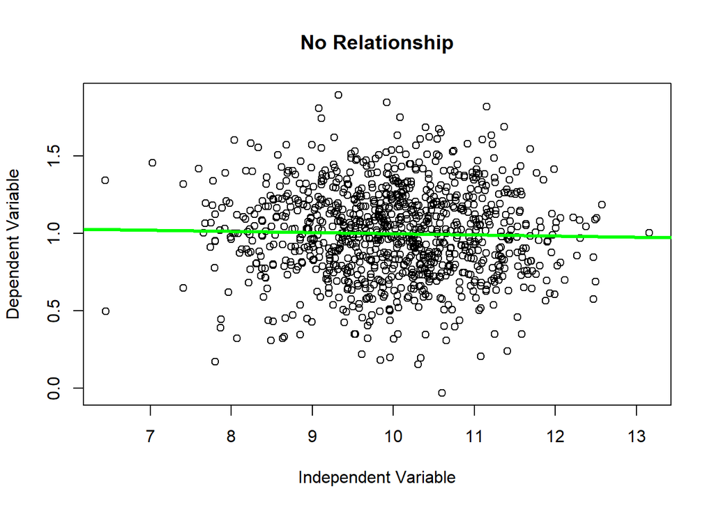

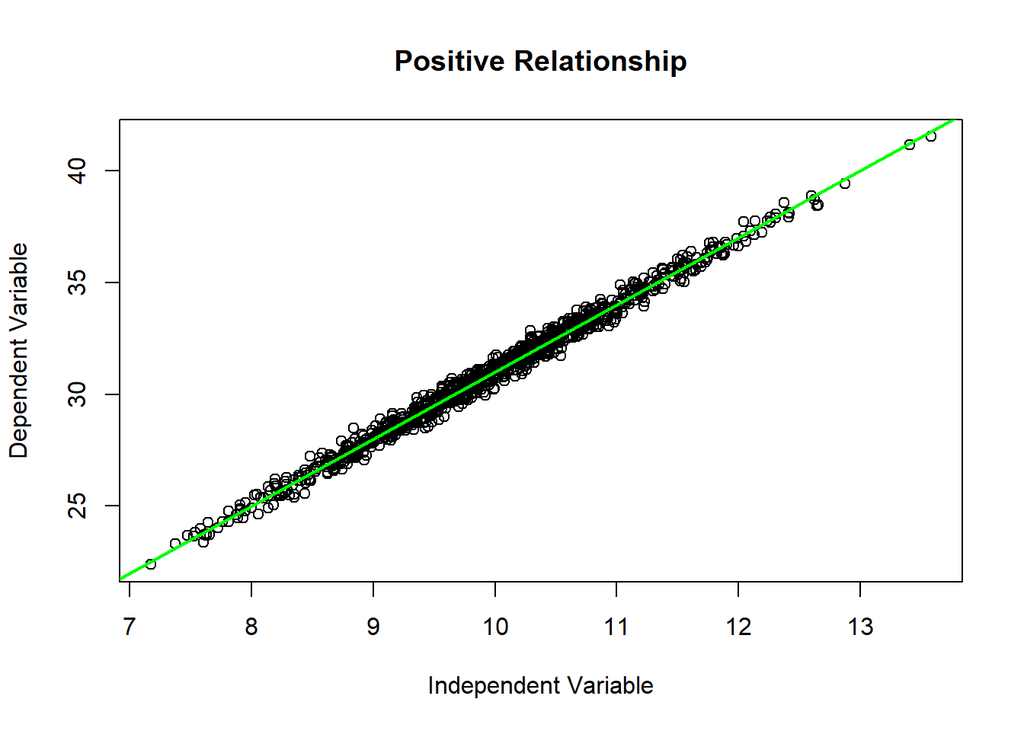

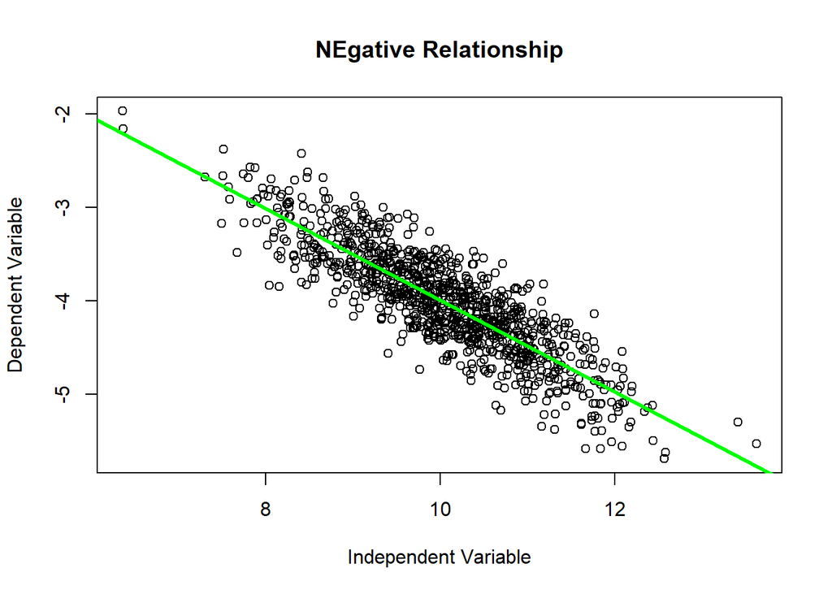

Always watch out for **outliers**. Linear regressions are very sensitive to outliers. Which are observations that are very abnormal in the dataset. Let’s see how the an outlier in our first plot changes the regression line. Let’s add the point (15, 0) to our data.

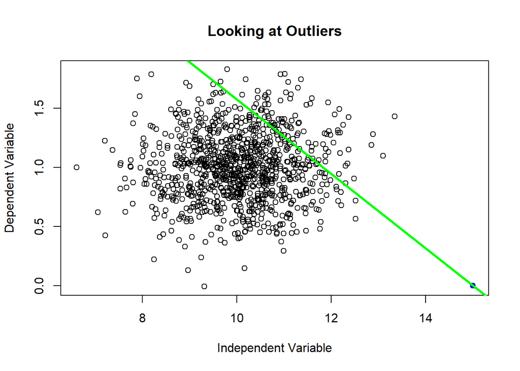

The **number of observations** also matter a lot. Let’s see how:

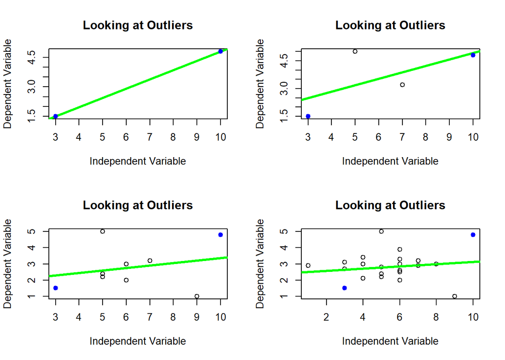

Conclusion: the more data you have the more stable would be your results. Furthermore, always produce a scatter of your main variables to check for outliers and visual expectations of the correlation.

### How to use `lm` for calculating linear models

Let’s go back to our Brazilian example. To calculate an OLS regression we will use the`lm` command. I’ll leave to your future TAs to explain how to do this “by hand” when you start your methods sequence at your PhD!!

The command has the following basic structure: lm(formula, data). There are more arguments but we don’t need to go very deep into them. The `formula` will capture your regression formula and the `data` the dataset you will be using.

#### The `lm` command

Let’s first try to answer if race has an influence on income. We will be assuming here that our income variable is continuous. Formally:

$$income_i = \beta_0 +\beta_1race_i +
\epsilon_i$$

```r
# Let's calculate the model. Remember lm(formula, data)
model1 <- lm(formula = income ~ race2_rec, data = brazil)

# Look that now you have a new object in your environment called model 1. This object stores a lot of useful information about your model. We will focus right now in the coefficients.

# Let's see the results and try to understand what they mean
summary(model1)
```

```
##
## Call:
## lm(formula = income ~ race2_rec, data = brazil)
##
## Residuals:
##     Min      1Q  Median      3Q     Max
## -1.9274 -0.5481  0.0726  0.4519  4.4519
##
## Coefficients:
##             Estimate Std. Error t value Pr(>|t|)
## (Intercept)  2.92739    0.03065   95.51   <2e-16 ***
## race2_rec   -0.37928    0.04005   -9.47   <2e-16 ***
## ---
## Signif. codes:  0 '***' 0.001 '**' 0.01 '*' 0.05 '.' 0.1 ' ' 1
##
## Residual standard error: 1.011 on 2624 degrees of freedom
##   (450 observations deleted due to missingness)
## Multiple R-squared:  0.03305,    Adjusted R-squared:  0.03268
## F-statistic: 89.68 on 1 and 2624 DF,  p-value: < 2.2e-16
```

```r
# You first are interested in the magnitude and direction of your coefficients. Your coefficients are estimates of the line's slope and are the same as the correlation between your variables (in the univariate world). Positive coefficients mean positive correlations. Negative coefficients mean negative correlations.

# We can get a vector of coefficients (or betas) using the coefficient formula
coefficients(model1)
```

```
## (Intercept)   race2_rec
##   2.9273897  -0.3792753
```

```r
# or extracting the data from our summary table
summary(model1)$coefficients[, 1]
```

```
## (Intercept)   race2_rec
##   2.9273897  -0.3792753
```

```r
# Given that our data is just a sample of the population, we don't know what the real parameter for our slope (correlation) actually is. As a result, we must have some uncertainty around our estimate. This uncertainty can be calculated using the standard error. In fact, we can construct our confidence intervals using this information.
# We can do this manually
summary(model1)$coefficients[, 1]+1.96*summary(model1)$coefficients[, 2]
```

```
## (Intercept)   race2_rec
##   2.9874663  -0.3007744
```

```r
summary(model1)$coefficients[, 1]-1.96*summary(model1)$coefficients[, 2]
```

```
## (Intercept)   race2_rec
##   2.8673131  -0.4577762
```

```r
# or using the confint command
confint(model1)
```

```
##                 2.5 %     97.5 %
## (Intercept)  2.867286  2.9874930
## race2_rec   -0.457811 -0.3007396
```

According to the results being Afro-Brazilian is associated with a decrease of -0.38 points of income. More substantially, there is statistical support to the idea that black Brazilians earn less than their non-Black counterparts.

#### Does race and access to governmental programs affect participation in elections?

What are the effects of race and access to the government program of Bolsa Familia (bf) into voting in the first round of elections.

```r
# Calculate this bivariate relationship and call it model2
model2 <- ______(______ ~ race2_rec + bf1, data=______)
# call the summary of model2
_______(model2)

# What are the confidence intervals for model 2
_______(model2)

# Let's add income and pt as control variables and call it model3
model3 <- ______(______ ~ ____ + _____ + ______ + ___, data=______)
# call the summary of model3
________(model3)

# What is the coefficient for bf1 in model3
_____(model3)[_]

# Let's also calculate a model just with the intercept and call it model4
model4 <- lm(____ ~ 1, ________)
________(model5)
```

#### Non-mandatory homework

Do access to governmental programs and race affect voting for the incumbent on the runoff elections?

```
##                  Estimate  Std. Error     t value
## (Intercept)  0.8092032556 0.023508681 34.42146571
## race2_rec   -0.0004987277 0.014306378 -0.03486052
## bf1          0.0250185799 0.015652753  1.59835017
## pt           0.0256177214 0.070579177  0.36296430
## income       0.0146502339 0.006888132  2.12688055
```

## **Goodness of Fit and `stargazer`**

This last section will focus on how to compare across models and how to export this output using `stargazer`. Let’s first understand how stargazer works. I found this stargazer [webpage](https://www.jakeruss.com/cheatsheets/stargazer/#omit-parts-of-the-default-output) very useful.

We calculated three models in the last section. How to know which one is the best? There are two main ways to do so. First, is comparing the **F-tests**. This F-test compares the goodness of fit for models with covariates vs a model with just the intercept. It formally tests if all the coefficients are different from zero or not. In plain English it shows if adding covariates help the fit of the model.:

$$H_o: \beta_i = \beta_j = \beta_k = ...
= 0$$
$$H_a:\beta_i \neq \beta_j \neq
\beta_k = ... \neq 0$$

```r
# stargazer(model1, model2, type = "type)
# The types could be text, hetml or latex
stargazer(model4, model2, model3, type="text")
```

```
##
## =================================================================================
##                                          Dependent variable:
##                     -------------------------------------------------------------
##                                               turnout1a
##                            (1)                 (2)                   (3)
## ---------------------------------------------------------------------------------
## race2_rec                                    -0.008                -0.010
##                                              (0.013)               (0.014)
##
## bf1                                          0.033**               0.037**
##                                              (0.015)               (0.016)
##
## pt                                                                  0.106
##                                                                    (0.070)
##
## income                                                              0.010
##                                                                    (0.007)
##
## Constant                0.852***            0.849***              0.824***
##                          (0.006)             (0.010)               (0.023)
##
## ---------------------------------------------------------------------------------
## Observations              3,071               2,987                 2,620
## R2                        0.000               0.002                 0.004
## Adjusted R2               0.000               0.001                 0.002
## Residual Std. Error 0.355 (df = 3070)   0.354 (df = 2984)     0.350 (df = 2615)
## F Statistic                           2.607* (df = 2; 2984) 2.338* (df = 4; 2615)
## =================================================================================
## Note:                                                 *p<0.1; **p<0.05; ***p<0.01
```

To answer this question we need to compare the $R^2$ which is the percentage of the dependent variable’s variance explained by the model. In this case, column three the model with the controls explains 0.4% of the total variance in our dependent variable. That is not much!!!

**Pro-question**: Why is our number of observations changing on each model?

```r
# You can also use stargazer to calculate descriptive statistic
# stargazer(data)
stargazer(brazil, type="text")
```

```
##
## =================================================================
## Statistic       N    Mean  St. Dev.  Min  Pctl(25) Pctl(75)  Max
## -----------------------------------------------------------------
## income        2,701 2.702   1.032   1.000  2.000    3.000   7.000
## educ          2,959 2.544   1.043   1.000  2.000    3.000   5.000
## female        3,076 0.527   0.499     0      0        1       1
## age           3,076 41.612  15.785   16      29       54     89
## turnout1a     3,071 0.852   0.355   0.000  1.000    1.000   1.000
## turnout2a     3,053 0.854   0.353   0.000  1.000    1.000   1.000
## pt            3,073 0.008   0.090   0.000  0.000    0.000   1.000
## bf1           3,076 0.277   0.448     0      0        1       1
## bf2           3,076 0.277   0.448     0      0        1       1
## race2_rec     2,992 0.578   0.494   0.000  0.000    1.000   1.000
## vote1b_rec    2,563 0.499   0.500   0.000  0.000    1.000   1.000
## vote2b_rec    2,571 0.567   0.496   0.000  0.000    1.000   1.000
## hs            2,959 0.183   0.387   0.000  0.000    0.000   1.000
## schooled_Afro 2,970 0.082   0.274   0.000  0.000    0.000   1.000
## -----------------------------------------------------------------
```

```r
# you can change the styles of the tables
stargazer(model4, model2, model3, type="text", style="ajps")
```

```
##
## ---------------------------------------------------------------------------------
##                                               turnout1a
##                          Model 1             Model 2               Model 3
## ---------------------------------------------------------------------------------
## race2_rec                                    -0.008                -0.010
##                                              (0.013)               (0.014)
## bf1                                          0.033**               0.037**
##                                              (0.015)               (0.016)
## pt                                                                  0.106
##                                                                    (0.070)
## income                                                              0.010
##                                                                    (0.007)
## Constant                0.852***            0.849***              0.824***
##                          (0.006)             (0.010)               (0.023)
## N                         3071                2987                  2620
## R-squared                 0.000               0.002                 0.004
## Adj. R-squared            0.000               0.001                 0.002
## Residual Std. Error 0.355 (df = 3070)   0.354 (df = 2984)     0.350 (df = 2615)
## F Statistic                           2.607* (df = 2; 2984) 2.338* (df = 4; 2615)
## ---------------------------------------------------------------------------------
## ***p < .01; **p < .05; *p < .1
```

```r
# you can add titles and put more understandable names to the variables
stargazer(model4, model2, model3, type="text",
          title            = "Results Table 1",
          covariate.labels = c("Afro-Brazilian", "Bolsa Familia Recipient", "Partisan of PT",
                               "Income"),
          dep.var.caption  = "OLS Models",
          dep.var.labels   = "Voted in the First Round of elections")
```

```
##
## Results Table 1
## =====================================================================================
##                                                  OLS Models
##                         -------------------------------------------------------------
##                                     Voted in the First Round of elections
##                                (1)                 (2)                   (3)
## -------------------------------------------------------------------------------------
## Afro-Brazilian                                   -0.008                -0.010
##                                                  (0.013)               (0.014)
##
## Bolsa Familia Recipient                          0.033**               0.037**
##                                                  (0.015)               (0.016)
##
## Partisan of PT                                                          0.106
##                                                                        (0.070)
##
## Income                                                                  0.010
##                                                                        (0.007)
##
## Constant                    0.852***            0.849***              0.824***
##                              (0.006)             (0.010)               (0.023)
##
## -------------------------------------------------------------------------------------
## Observations                  3,071               2,987                 2,620
## R2                            0.000               0.002                 0.004
## Adjusted R2                   0.000               0.001                 0.002
## Residual Std. Error     0.355 (df = 3070)   0.354 (df = 2984)     0.350 (df = 2615)
## F Statistic                               2.607* (df = 2; 2984) 2.338* (df = 4; 2615)
## =====================================================================================
## Note:                                                     *p<0.1; **p<0.05; ***p<0.01
```

```r
# You can also omit some of the statistics
stargazer(model4, model2, model3, type="text",
          title            = "Results Table 1",
          covariate.labels = c("Afro-Brazilian", "Bolsa Familia Recipient", "Partisan of PT",
                               "Income"),
          dep.var.caption  = "OLS Models",
          dep.var.labels   = "Voted in the First Round of elections",
          omit.stat = c("f"))
```

```
##
## Results Table 1
## =============================================================================
##                                              OLS Models
##                         -----------------------------------------------------
##                                 Voted in the First Round of elections
##                                (1)               (2)               (3)
## -----------------------------------------------------------------------------
## Afro-Brazilian                                 -0.008            -0.010
##                                                (0.013)           (0.014)
##
## Bolsa Familia Recipient                        0.033**           0.037**
##                                                (0.015)           (0.016)
##
## Partisan of PT                                                    0.106
##                                                                  (0.070)
##
## Income                                                            0.010
##                                                                  (0.007)
##
## Constant                    0.852***          0.849***          0.824***
##                              (0.006)           (0.010)           (0.023)
##
## -----------------------------------------------------------------------------
## Observations                  3,071             2,987             2,620
## R2                            0.000             0.002             0.004
## Adjusted R2                   0.000             0.001             0.002
## Residual Std. Error     0.355 (df = 3070) 0.354 (df = 2984) 0.350 (df = 2615)
## =============================================================================
## Note:                                             *p<0.1; **p<0.05; ***p<0.01
```

```r
# You can choose which variables to present, add info and export
stargazer(model4, model2, model3, type="text",
          title            = "Results Table 1",
          covariate.labels = c("Afro-Brazilian", "Bolsa Familia Recipient", "Partisan of PT",
                               "Income"),
          dep.var.caption  = "OLS Models",
          dep.var.labels   = "Voted in the First Round of elections",
          omit.stat = c("f"),
          add.lines = list(c("Comtrols", "No", "No", "Yes")),
          keep = c("race2","bf1"),
          out="table1.doc") # for nicer looking exported tables change text for html in type
```

```
##
## Results Table 1
## =============================================================================
##                                              OLS Models
##                         -----------------------------------------------------
##                                 Voted in the First Round of elections
##                                (1)               (2)               (3)
## -----------------------------------------------------------------------------
## Afro-Brazilian                                 -0.008            -0.010
##                                                (0.013)           (0.014)
##
## Bolsa Familia Recipient                        0.033**           0.037**
##                                                (0.015)           (0.016)
##
## -----------------------------------------------------------------------------
## Comtrols                       No                No                Yes
## Observations                  3,071             2,987             2,620
## R2                            0.000             0.002             0.004
## Adjusted R2                   0.000             0.001             0.002
## Residual Std. Error     0.355 (df = 3070) 0.354 (df = 2984) 0.350 (df = 2615)
## =============================================================================
## Note:                                             *p<0.1; **p<0.05; ***p<0.01
```

## **Functions used in this lab**

The functions we used today are:

- `lm`
- `ifelse`
- `mutate`
- `stargazer`
- `summary`
- `coefficients`
- `confint`

## **Additional resources**

- Here is a [nice tutorial](https://cran.r-project.org/web/packages/rio/vignettes/rio.html) for importing and exporting a wide array of files into R.